# Statistics for decision Making

## Importing required packages:

```python
import numpy as np
import pandas as pd
import matplotlib.pyplot as plt
import seaborn as sns
from scipy.stats import norm
import scipy.stats as stats
from warnings import filterwarnings
filterwarnings('ignore')
```

## Problem Statement:

Cold Storage started its operations in Jan 2016. They are in the business of storing Pasteurized Fresh Whole or Skimmed Milk, Sweet Cream, Flavoured Milk Drinks. To ensure that there is no change of texture, body appearance, separation of fats the optimal temperature to be maintained is between 2º - 4º C.

In the first year of business, they outsourced the plant maintenance work to a professional company with stiff penalty clauses. It was agreed that if it was statistically proven that the probability of temperature going outside the 2º - 4º C during the one-year contract was above 2.5% and less than 5% then the penalty would be 10% of AMC (annual maintenance case). In case it exceeded 5% then the penalty would be 25% of the AMC fee

## Reading the Dataset:

```python
df1=pd.read_csv('Cold_Storage_Temp_Data_ (2).csv')
```

## Checking the head and tail of Dataset:

```python
df1.head()
```

|  | Season | Month | Date | Temperature |
| --- | --- | --- | --- | --- |
| 0 | Winter | Jan | 1 | 2.3 |
| 1 | Winter | Jan | 2 | 2.2 |
| 2 | Winter | Jan | 3 | 2.4 |
| 3 | Winter | Jan | 4 | 2.8 |
| 4 | Winter | Jan | 5 | 2.5 |

```python
df1.tail()
```

|  | Season | Month | Date | Temperature |
| --- | --- | --- | --- | --- |
| 360 | Winter | Dec | 27 | 2.7 |
| 361 | Winter | Dec | 28 | 2.3 |
| 362 | Winter | Dec | 29 | 2.6 |
| 363 | Winter | Dec | 30 | 2.3 |
| 364 | Winter | Dec | 31 | 2.9 |

#### Inference:

Dataset has 365 rows and 4 columns.

Dataset has both numerical and catagorical variables.

Numerical variables are date and Temperature.

Categorical varible has Month and Season.

There is no null values in dataset.

There is no duplicate values in dataset.

## Shape of Dataset:

```python
df1.shape
print('Number of rows',df1.shape[0])
print('Number of cloumns',df1.shape[1])
```

```
Number of rows 365
Number of cloumns 4
```

## Checking Info in Dataset:

```python
df1.info()
```

```
<class 'pandas.core.frame.DataFrame'>
RangeIndex: 365 entries, 0 to 364
Data columns (total 4 columns):
 #   Column       Non-Null Count  Dtype
---  ------       --------------  -----
 0   Season       365 non-null    object
 1   Month        365 non-null    object
 2   Date         365 non-null    int64
 3   Temperature  365 non-null    float64
dtypes: float64(1), int64(1), object(2)
memory usage: 11.5+ KB
```

## Checking Null Values in Dataset:

```python
df1.isnull().sum().sum()
```

```
0
```

## Checking duplicates in dataset:

```python
dups = df1.duplicated()
print('Number of duplicate rows = %d' % (dups.sum()))
df1[dups]
```

```
Number of duplicate rows = 0
```

|  | Season | Month | Date | Temperature |
| --- | --- | --- | --- | --- |

## Skewness of Data:

```python
df1.skew()
```

```
Date           0.007552
Temperature    0.238751
dtype: float64
```

## Summary of Dataset:

```python
pd.DataFrame(round(df1['Temperature'].describe(include='all'),2))
```

|  | Temperature |
| --- | --- |
| count | 365.00 |
| mean | 3.00 |
| std | 0.47 |
| min | 1.70 |
| 25% | 2.70 |
| 50% | 3.00 |
| 75% | 3.30 |
| max | 4.50 |

#### Inference:

Total count of days is 365.

Mean of temperature is 3.00 and Standard deviation is 0.47.

Mean,Median and Mode are equal so it seems to normal distribution.

Minimum Temperature is 1.7 degree celsius and maximum temperature is 4.50 degree celsius.

## univariate Analysis:

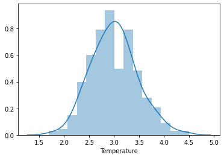

```python
sns.distplot(df1['Temperature'],bins=15,kde=True)
plt.show()
```

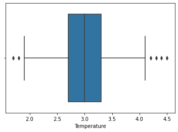

```python
sns.boxplot(df1['Temperature'])
plt.show()
```

#### Inference:

Mean,Median and Mode are equal so it seems to normal distribution.

Outliers are present in the data.

## Bivariate Analysis:

#### Temperature VS Month:

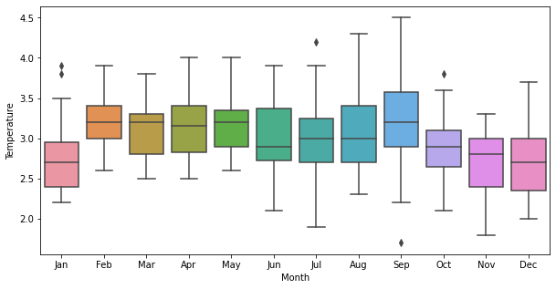

```python
plt.figure(figsize=(10,5))
sns.boxplot(df1['Month'],df1['Temperature'])
plt.show()
```

#### Inference:

Jan,July,September and October has outliers.

Mar, May, Feb, Apr, Oct are negatively skewed.

Normal Distribution is not observed in any month.

#### Temperature VS Season:

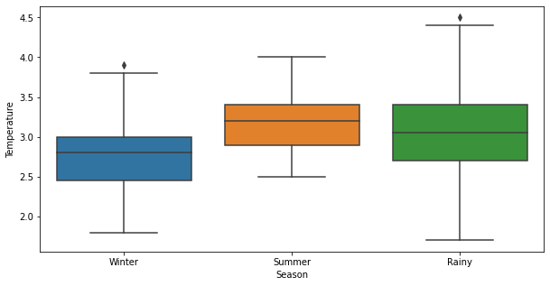

```python
plt.figure(figsize=(10,5))
sns.boxplot(df1['Season'],df1['Temperature'])
plt.show()
```

#### Inference:

1 Outliers in the Winter season, 1 in Rainy, whereas no Outliers in Summer.

Rainy season has temperature higher than 4 Degree Celsius and lower than 2 Degree Celsius.

Winter seson has recorded temperature lower than 2 degree Celsius.

#### Month VS Temperature with Season:

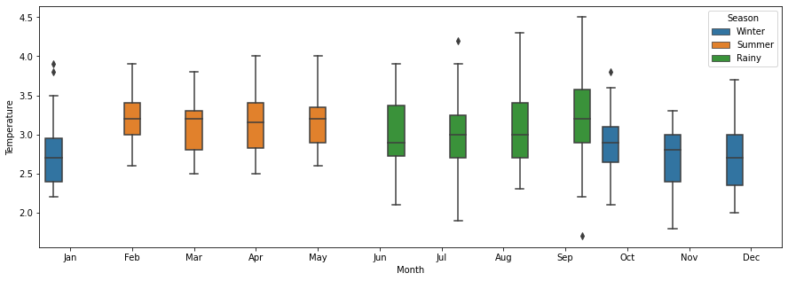

```python
plt.figure(figsize=(15,5))
sns.boxplot(df1['Month'],df1['Temperature'],hue=df1['Season'])
plt.show()
```

#### Inference:

Summer corresponds to the months of Feb to May.

Rainy corresponds to June to September.

Winter corresponds to Jan & Oct to Dec.

Going by the nature of these 2 variables, which being straight-forward,nothing substantial can be inferred statistically.

### 1.Find mean cold storage temperature for Summer, Winter, and Rainy Season.

```python
Temp=round(df1.groupby('Season').mean()['Temperature'],2)
print('Mean cold storage temperature for Rainy season:',Temp[0])
print('Mean cold storage temperature for Summer season:',Temp[1])
print('Mean cold storage temperature for Winter season:',Temp[2])
```

```
Mean cold storage temperature for Rainy season: 3.09
Mean cold storage temperature for Summer season: 3.15
Mean cold storage temperature for Winter season: 2.78
```

#### Inference:

From the dataset under analysis, it can be observed that the highest average temperature is being clocked for the season of Summer whereas the lowest is for Winter.

Although once can assume this to match the natural ambient temperatures of different seasons, statistically we cannot draw a conclusion due to the lack of weather data across the year.

### 2.Find the overall mean for the full year

```python
mean=df1['Temperature'].mean()
print('overall mean for the full year:',mean)
```

```
overall mean for the full year: 3.0024657534246546
```

### 3.Find Standard Deviation for the full year.

```python
std=df1['Temperature'].std()
print('Standard Deviation for the full year:',std)
```

```
Standard Deviation for the full year: 0.4658319416510761
```

### 4.Assume Normal distribution, what is the probability of temperature having fallen below 2º C?

```python
df1[df1['Temperature']<2]
```

|  | Season | Month | Date | Temperature |
| --- | --- | --- | --- | --- |
| 203 | Rainy | Jul | 23 | 1.9 |
| 271 | Rainy | Sep | 29 | 1.7 |
| 306 | Winter | Nov | 3 | 1.8 |

```python
print('probability of temperature having fallen below 2ºC:',stats.norm.cdf(2,loc=3.002,scale=0.465)*100)
```

```
probability of temperature having fallen below 2ºC: 1.5587228958846788
```

### 5.Assume Normal distribution, what is the probability of temperature having gone above 4º C?

```python
print('probability of temperature having gone above 4º C:',(1-stats.norm.cdf(4,loc=3.002,scale=0.465))*100)
```

```
probability of temperature having gone above 4º C: 1.5927055086573216
```

```python
df1[df1['Temperature']>4]
```

|  | Season | Month | Date | Temperature |
| --- | --- | --- | --- | --- |
| 190 | Rainy | Jul | 10 | 4.2 |
| 233 | Rainy | Aug | 22 | 4.3 |
| 244 | Rainy | Sep | 2 | 4.1 |
| 248 | Rainy | Sep | 6 | 4.1 |
| 250 | Rainy | Sep | 8 | 4.1 |
| 251 | Rainy | Sep | 9 | 4.5 |
| 262 | Rainy | Sep | 20 | 4.4 |

### 6.What will be the penalty for the AMC Company

```python
print('Probability of Temperature:',(stats.norm.cdf(2,loc=3.002,scale=0.465)+(1-stats.norm.cdf(4,loc=3.002,scale= 0.465)))*100)
```

```
Probability of Temperature: 3.1514284045420005
```

#### Inference:

A particular Temperature can never attain a value lower than 2 and higher than 4 at the same time, therefore these 2 are mutually exclusive events, thus P (A U B) = P(A) + P(B)Therefore, P = P(Temp<2) + P(Temp>4) =3.15%

##### Therefore penalty = 10% of AMC,Since the probability of Temperature going outside of the range of 2–4 degree Celsius falls between the 2.5% and 5% boundary as mentioned on the problem statement.

# Problem 2

In Mar 2018, Cold Storage started getting complaints from their clients that they have been getting complaints from end consumers of the dairy products going sour and often smelling. On getting these complaints, the supervisor pulls out data of the last 35 days’ temperatures. As a safety measure, the Supervisor has been vigilant to maintain the mean temperature 3.9º C or below.

Assume 3.9º C as the upper acceptable mean temperature and at alpha = 0.1 do you feel that there is a need for some corrective action in the Cold Storage Plant or is it that the problem is from the procurement side from where Cold Storage is getting the Dairy Products.

## Reading the Dataset:

```python
df2=pd.read_csv('Cold_Storage_Mar2018__(3) (1).csv')
```

## Checking the head and tail of Dataset:

```python
df2.head()
```

|  | Season | Month | Date | Temperature |
| --- | --- | --- | --- | --- |
| 0 | Summer | Feb | 11 | 4.0 |
| 1 | Summer | Feb | 12 | 3.9 |
| 2 | Summer | Feb | 13 | 3.9 |
| 3 | Summer | Feb | 14 | 4.0 |
| 4 | Summer | Feb | 15 | 3.8 |

```python
df2.tail()
```

|  | Season | Month | Date | Temperature |
| --- | --- | --- | --- | --- |
| 30 | Summer | Mar | 13 | 4.2 |
| 31 | Summer | Mar | 14 | 4.2 |
| 32 | Summer | Mar | 15 | 3.8 |
| 33 | Summer | Mar | 16 | 3.9 |
| 34 | Summer | Mar | 17 | 3.9 |

#### Inference:

Dataset has 35 rows and 4 columns.

Dataset has both numerical and catagorical variables.

Numerical variables are date and Temperature.

Categorical varible has Month and Season.

There is no null values in dataset.

There is no duplicate values in dataset.

## Shape of Dataset:

```python
print('Number of rows:',df2.shape[0])
print('Number of column:',df2.shape[1])
```

```
Number of rows: 35
Number of column: 4
```

## Checking Info in Dataset:

```python
df2.info()
```

```
<class 'pandas.core.frame.DataFrame'>
RangeIndex: 35 entries, 0 to 34
Data columns (total 4 columns):
 #   Column       Non-Null Count  Dtype
---  ------       --------------  -----
 0   Season       35 non-null     object
 1   Month        35 non-null     object
 2   Date         35 non-null     int64
 3   Temperature  35 non-null     float64
dtypes: float64(1), int64(1), object(2)
memory usage: 1.2+ KB
```

## Checking Null Values in Dataset:

```python
count=df2.isnull().sum().sum()
print('Number of null values in Dataset:',count)
```

```
Number of null values in Dataset: 0
```

## Checking duplicates in dataset:

```python
dups=df2.duplicated().sum()
print('number of duplicates:%d'%(dups))
```

```
number of duplicates:0
```

## Summary of Dataset:

```python
pd.DataFrame(round(df2['Temperature'].describe(include='all'),2))
```

|  | Temperature |
| --- | --- |
| count | 35.00 |
| mean | 3.97 |
| std | 0.16 |
| min | 3.80 |
| 25% | 3.90 |
| 50% | 3.90 |
| 75% | 4.10 |
| max | 4.60 |

```python
df2['Season'].value_counts()
```

```
Summer    35
Name: Season, dtype: int64
```

```python
df2['Month'].value_counts()
```

```
Feb    18
Mar    17
Name: Month, dtype: int64
```

#### Inference:

Minimum temperature recorded is 3.8 degree celsius and Minimum temperature recorded is 4.60 degree celsius.

Only Summer season is taken for analysis.

## univariate Analysis:

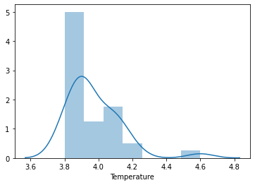

```python
sns.distplot(df2['Temperature'],kde=True)
plt.show()
```

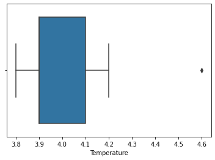

```python
sns.boxplot(df2['Temperature'])
plt.show()
```

#### Inference:

Most of the temperature is distributed between in 3.8 to 4.2 degree celsius.

From the Temperature boxplot, we can observe a very heavy Positive skewness in the data distribution.

A single outlier seen that is quite off from the Max value.

## Bivariate Analysis:

#### Temperature VS Month:

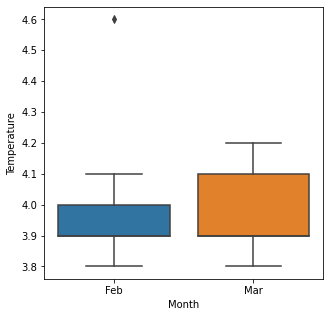

```python
plt.figure(figsize=(5,5))
sns.boxplot(df2['Month'],df2['Temperature'])
plt.show()
```

#### Temperature VS Season:

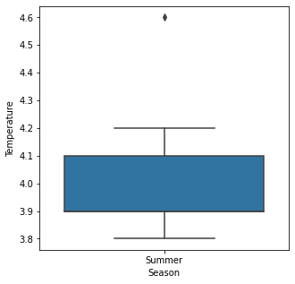

```python
plt.figure(figsize=(5,5))
sns.boxplot(df2['Season'],df2['Temperature'])
plt.show()
```

#### Month VS Temperature with Season:

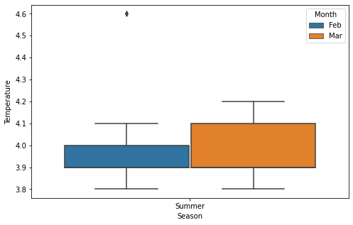

```python
plt.figure(figsize=(8,5))
sns.boxplot(df2['Season'],df2['Temperature'],hue=df2['Month'])
plt.show()
```

#### Date VS Temperature with Month:

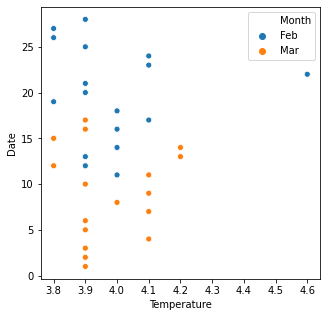

```python
plt.figure(figsize=(5,5))
sns.scatterplot(df2['Temperature'],df2['Date'],hue=df2['Month'])
plt.show()
```

#### Inference:

Feb Month has recorded the highest temperature of 4.6

### 1. Which Hypothesis test shall be performed to check if corrective action is needed at the cold storage plant? Justify your answer

In a Hypothesis test scenario, if the sample mean is largely representative of the population mean, then we use a One-tailed T-Test. When the testing is done to show that the sample mean would be higher or lower than the population mean, it is referred to as a one-tailed test. (The basis assumption of Normal distribution of data,however, is necessary)

For determining this, we require a Null & Alternate Hypothesis to be determined before carrying out such test. In this case, the supervisor needs to understand if the mean temperature of last 35 days falls below 3.9 C or not,hence in this case, a one tailed t-test would be the best suited, since the test is largely towards one side of thedata or towards single tail.

### 2.State the Hypothesis and do the necessary calculations to accept or reject the corresponding null hypothesis

We now have the data of 35 days temperatures of dairy products. Supervisor is setting an upper acceptable valueof 3.9 C and alpha = 0.1, hence the confidence interval in such case is 90% or 0.90

We now state the Null & Alternate Hypothesis for the case in question.

Null Hypothesis, H0: Mu<=3.9 C

Alternate Hypothesis, Ha: Mu>3.9 C

```python
from scipy.stats import   ttest_1samp
```

```python
# one sample t-test
# null hypothesis: expected value = 3.9
t_statistic, p_value = ttest_1samp(df2['Temperature'], 3.9)
print('One sample t test \nt statistic: {0} p value: {1} '.format(t_statistic, p_value))
```

```
One sample t test
t statistic: 2.752358609800241 p value: 0.009422395404264431
```

```python
# p_value < 0.05 => alternative hypothesis:

alpha_value = 0.05 # Level of significance
print('Level of significance: %.2f' %alpha_value)
if p_value < alpha_value:
    print('We have evidence to reject the null hypothesis since p value < Level of significance')
else:
    print('We have no evidence to reject the null hypothesis since p value > Level of significance')

print ("Our one-sample t-test p-value=", p_value)
```

```
Level of significance: 0.05
We have evidence to reject the null hypothesis since p value < Level of significance
Our one-sample t-test p-value= 0.009422395404264431
```

#### It is proved with a statistical significance that the mean temperature is more than the expected 3.9 C and hence, a corrective action is needed at the Cold Storage plant.

### 3.Give your inference

In other words, given the facts of the case, it is proved with a statistical significance that the mean temperature is more than the expected 3.9 C and hence, a corrective action is needed at the Cold Storage plant.

Hence corrective measures are required by cold storage owner against the contracted company to avoid any such failures in future because such failures can lead in loss ofcustomer on large scale.

Statistically we can conclude that there needs to be corrective measures taken to keep the Cold Storage function properly, and there is no apparent problem (statistically speaking) fromprocurement side from where Cold Storage is getting the DairyProducts.

We will submit the results to the owner of the Cold Storage and they need to figure out the resolution path, is it the lackadaisical approach in work by the Supervisor or some inherent problems with the machines being used. This,we cannot conclude statistically due to lack of necessary data.